# Project Assignment

### **Author**: A. Lam

## Summary

In this study, a dataset that consists of five different personal activities collected from accelerometers wore in different places in the body. The participants performed barbell lifts in 5 different ways. The goal of this project is to predict the manner in which they did the exercise using techniques learned in the course. The best method is then used to predict the activity in the test dataset.

## Analysis

Loading all the necessary libraries and dataset, and set the seed to make the analysis reproducible.

```r
library(caret)
library(doParallel)
library(ggpubr)

set.seed(123456)
train.data <- read.csv('pml-training.csv');
test.data <- read.csv('pml-testing.csv');
```

The data contains some columns that are not necessary for the analysis. Making some cleaning:

```r
has.na <- which(as.vector(sapply(train.data, function(x) sum(is.na(x))))!=0)
train.data <- train.data[,-has.na][, -c(1:7)]
test.data <- test.data[,-has.na][, -c(1:7)]
```

The training dataset is split into a train and test subsets:

```r
subset.train <- createDataPartition(train.data$classe, p=0.8, list=FALSE)
train.portion <- train.data[subset.train, ]
test.portion <- train.data[-subset.train, ]
```

The goal here is to find the best model that predicts the test set of 20 points. The caret package has several methods, and they will be used to find out which one predict the best result. The methods used are k-Nearest Neighbors (knn), Gradient Boosting Machine (gbm), Random Forest (rf), and Linear Discrimination Analysis (lda). Setting the parameters for caret package:

```r
control <- trainControl(
  method = "cv",
  number = 10,
  p = 0.80,
  allowParallel = TRUE
)
metric <- "Accuracy"
methods.type <- c('knn', 'gbm', 'rf', 'lda')
```

Initializing some useful for the analysis:

```r
output.from.method <- vector(mode = "list", length = length(methods.type))
statistics.from.method <- vector(mode = "list",length = length(methods.type))

initial.variable <- rep(NA,5)
initial.df <- data.frame(
   value  = initial.variable,
   class  = initial.variable,
   method = initial.variable
)

sensitivity.df <- initial.df
specificity.df <- initial.df
precision.df   <- initial.df
prevalence.df  <- initial.df
```

Defining a function to save the outputs from each method:

```r
compute.stat.df <- function(x,y){
   df <- data.frame(
     value = x,
     class = c('A', 'B', 'C', 'D', 'E'),
     method = rep(y, 5)
   )
   rownames(df) <- NULL
   return(df)
}
```

The core of the program is performed in the section below. NOTE: This part takes some time. FYI, the R image is saved in the GitHub repo.

```r
cl <- makePSOCKcluster(5)
registerDoParallel(cl)
count <- 1
for (i in c(1:length(methods.type))){
   print(paste('Processing data using ', methods.type[i], sep=""))
   output.from.method[[i]] <- train(
     classe~.,
     data = train.portion,
     method = methods.type[i],
     metric = metric,
     preProcess = c("center", "scale"),
     trControl = control
   )

   statistics.from.method[[i]] <- confusionMatrix(
     predict(output.from.method[[i]], newdata=test.portion),
     test.portion$classe
   )

   temp.sensitivity <- compute.stat.df(
     (statistics.from.method[[i]])$byClass[,c(1)],
     methods.type[i]
   )

   temp.specificity <- compute.stat.df(
     (statistics.from.method[[i]])$byClass[,c(2)],
     methods.type[i]
   )

   temp.precision <- compute.stat.df(
     (statistics.from.method[[i]])$byClass[,c(3)],
     methods.type[i]
   )

   temp.prevalence <- compute.stat.df(
     (statistics.from.method[[i]])$byClass[,c(4)],
     methods.type[i]
   )

   if(count==1){
     sensitivity.df <- temp.sensitivity
     specificity.df <- temp.specificity
     precision.df   <- temp.precision
     prevalence.df  <- temp.prevalence
   } else {
     sensitivity.df <- rbind(sensitivity.df, temp.sensitivity)
     specificity.df <- rbind(specificity.df, temp.specificity)
     precision.df   <- rbind(precision.df, temp.precision)
     prevalence.df  <- rbind(prevalence.df,temp.prevalence)
   }
   count <- count + 1
}
on.exit(stopCluster(cl))

accuracy = sensitivity.df$value*prevalence.df$value +
   specificity.df$value*(1-prevalence.df$value)

accuracy.df <- data.frame(
   value = accuracy,
   class = rep(c('A', 'B', 'C', 'D', 'E'), length(methods.type)),
   method = rep(methods.type, each=5)
)
```

NOTE: Running the code above is time consuming depending on the machine specification. FYI, the Github repo contains the R image where the user can load and test the commands below quickly.

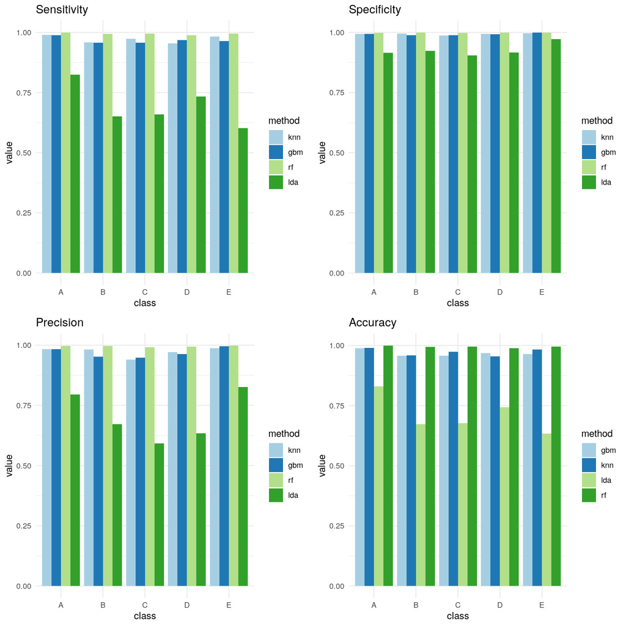

```r
load("pml_project.RData")
plotA <- ggplot(sensitivity.df, aes(x=class, y=value, fill=method)) +
    ggtitle("Sensitivity") +
    geom_bar(stat="identity", position=position_dodge()) +
    scale_fill_brewer(palette="Paired") + theme_minimal()

plotB <- ggplot(specificity.df, aes(x=class, y=value, fill=method)) +
    ggtitle("Specificity") +
    geom_bar(stat="identity", position=position_dodge()) +
    scale_fill_brewer(palette="Paired") + theme_minimal()

plotC <- ggplot(precision.df, aes(x=class, y=value, fill=method)) +
    ggtitle("Precision") +
    geom_bar(stat="identity", position=position_dodge()) +
    scale_fill_brewer(palette="Paired") + theme_minimal()

plotD <- ggplot(accuracy.df, aes(x=class, y=value, fill=method)) +
    ggtitle("Accuracy") +
    geom_bar(stat="identity", position=position_dodge()) +
    scale_fill_brewer(palette="Paired") + theme_minimal()

final.plot <- ggarrange(plotA, plotB, plotC, plotD, ncol = 2, nrow = 2)

final.plot
```

From the plots above, Random Forest (rf) predicts consistently well in all classes in comparison of the rest of the methods. Thus, we can use the Random Forest model to predict the result for the test data.

```r
data.frame(prediction=predict(output.from.method[[3]], newdata=test.data))
```

```
##    prediction
## 1           B
## 2           A
## 3           B
## 4           A
## 5           A
## 6           E
## 7           D
## 8           B
## 9           A
## 10          A
## 11          B
## 12          C
## 13          B
## 14          A
## 15          E
## 16          E
## 17          A
## 18          B
## 19          B
## 20          B
```

This result will be used in the quiz.